# PID Controller

## Introduction

The purpose of this project is make a PID Controller for Udacity simulator. The P, I and D factors were also tuned so the car in the simulator without driving off the road. The goal is to try to reduce the cte (Cross Track Error) as much as possible so that the car stays in the middle of the road.

To evaluate different, the PID values, the number of steps and the name of an output file were added as arguments for the pid executable. The output files were csv files with the step and cte values. These csv were used to create graphs to help visualize the effect of different PID values.

## Tuning

### P - proportional factor

With only the P factor set, the cte should oscillate around 0. P should be negative because we want to move proportionally in the opposite direction of the cte to try to correct the error. We'll compare the following P factors for 500 steps.

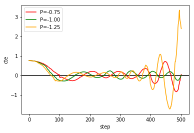

The best P value out of the 3 is -1.00. The controller oscillates closer to 0 for this P value.

### D - differential factor

We will use the best P value of -1.00 and compare D values from -50.0 to 0.0 for 2000 steps.

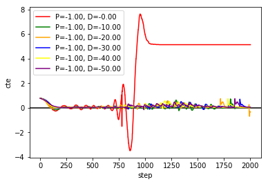

For D=0.0, the controller diverges from the y-axis at around 800 steps. The other D values seem to converge closely to 0.

Here we will remove D=0.0 and add D=-60.00 and D=-70.00 and increase the number of steps to 3000.

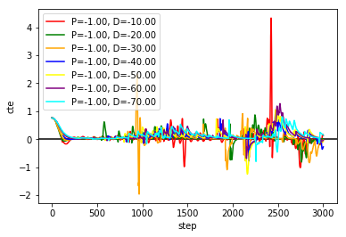

Clearly, we can eliminate D=-10.00 and D=-30.00 because of their large spikes. Let's repeat this with 4000 steps.

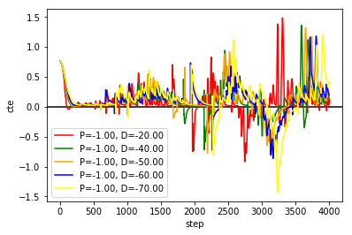

We can remote D=-20.0 and D=-70.0.

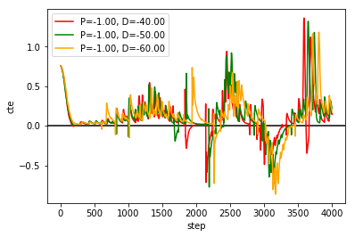

D=-50.0 appears to be the best out of the 3 factors.

### I - integral factor

To try to fine tune the steering of the car, we will look at I values from -0.04 to 0.0 for 5000 steps.

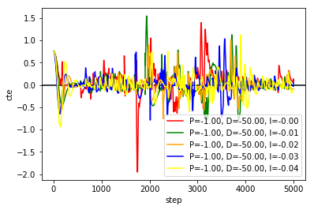

Clearly, we can eliminate I=0.0 and I=-0.01. Let's look at I from -0.04 to -0.02 at 7000 steps.

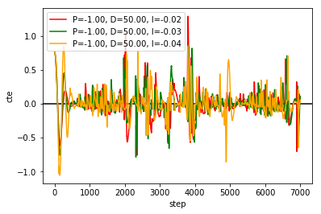

The best I value out of the 3 is -0.03.

## PID

Through trial and error, we found a reasonably good PID controller with the values of P=-1.00, D=-50.00, I=-0.03.

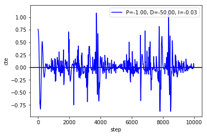